# Нарушенные сообщества и виды-индикаторы нарушений

## Выявление нарушенных сообществ зообетоса

```
## number of iterations= 33
```

Одним из самых очевидных признаков нарушенного местообитания является низкое, по сравнению с ненарушенными областями, обилие организмов в сообществе. Наиболее адекватной оценкой обилия было бы описание их продукционных характеристик. В нарушенном сообществе продукция должна быть низкой. Поэтому в качестве показателя, приближенно связанного с продукционными характеристиками сообщества, целесообразно использовать суммарную биомассу организмов. На рисунке (Рисунок 1) представлено частотное распределение значений логарифма суммарной биомассы всех донных животных на станции. Распределение этой величины имеет явный бимодальный характер. С помощью алгоритма, основанного на разделении смешанных распределений на отдельные совокупности (Bengalia et al., 2009), эмпирическое распределение было аппроксимировано совокупностью двух нормальных распределений ((Рисунок 1)). Параметры подобранных с помощью алгоритма двух аппроксимирующих распределений следующие: $\mu_1=$ -0.271, $\sigma_1=$ 0.765, $\mu_2=$ 3.072, $\sigma_2=$ 1.093.

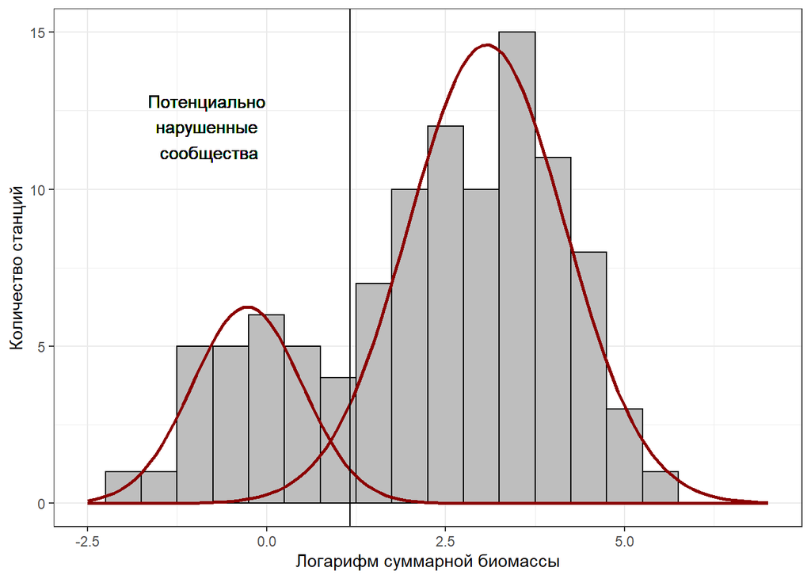

К числу станций, формующих левый пик в распределения относятся следующие: O10, O101, O105, O107, O108, O109, O11, O111, O12, O15, O37, O47, O53, O55, O62, O74, O78, O79, O81, O82, O83, O86, O92, O93, O98, O99. Можно заметить, что большинство станций из этой группы находятся в зоне техногенного воздействия (Рисунок 2)

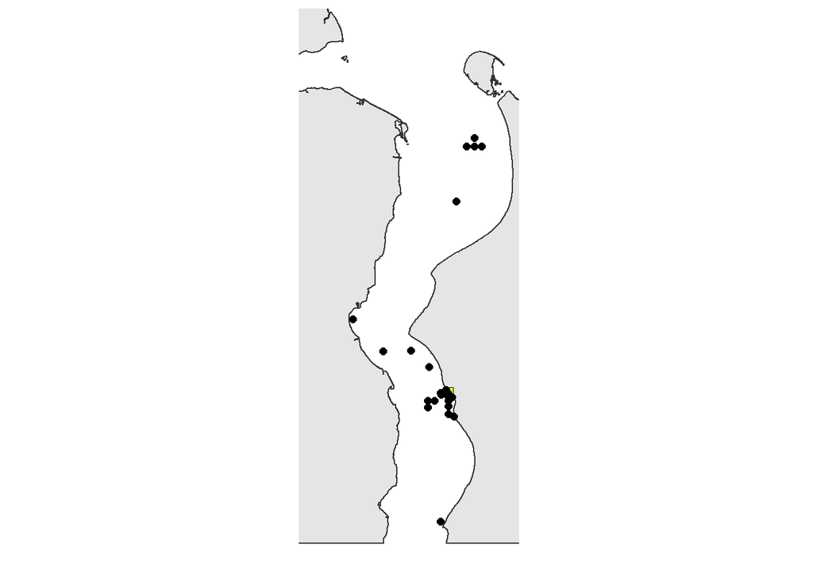